# Assignment 2

```r
# Set CRAN mirror explicitly for knitting / non-interactive runs
options(repos = c(CRAN = "https://cloud.r-project.org"))

knitr::opts_chunk$set(echo = TRUE, message = FALSE, warning = FALSE)
library(tidyverse)
library(rpart)
library(caret)
set.seed(1)
```

## Problem Overview

The goal is model selection and feature engineering. We will:

1. Set up the dataset by doing some preprocessing and feature engineering
2. Use robust model selection to compare models with different features
3. Interpret and evaluate your models
4. Make (new) predictions in the test dataset

## Introduction

YouTube is the world’s largest video-sharing platform. Videos can “trend” in one or more countries, and their popularity is influenced by many factors such as category, duration, channel, and engagement metrics.

## Data

There are more than 100,000 YouTube trending videos in the dataset. Each row contains metadata about a trending video, including its category, country, channel, engagement metrics, and more.

You are provided with the following files:

1. `yt_training_X.csv`: features for the training instances (videos published before a certain date).
2. `yt_training_y.csv`: labels for the target variable for the training instances.
3. `yt_test_X.csv`: features for the test instances (videos published after that date). Your goal is to make predictions for the instances in the test set.

For convenience, a smaller subset of the training data is also provided:

4. `yt_small_training_X.csv`
5. `yt_small_training_y.csv`

A “fake” test set of y-variable labels (all “NO”) is provided for coding convenience:

6. `yt_test_y_FAKE.csv`

## Assignment:-

## Setup

```r
#train_X <- read_csv("yt_small_training_X.csv")
#train_y <- read_csv("yt_small_training_y.csv")

train_X <- read_csv("yt_training_X.csv")
train_y <- read_csv("yt_training_y.csv")

test_X <- read_csv("yt_test_X.csv")
test_y <- read_csv("yt_test_y_FAKE.csv")

# join the X and y variables
train <- train_X %>%
  mutate(success = as.factor(train_y$success),
         original_set = "tr")

test <- test_X %>%
  mutate(success = as.factor(test_y$success),
         original_set = "te")

# stack the training and test data
all_data <- rbind(train, test)

new_data <- all_data %>%
  select(video_view_count, video_like_count, video_comment_count, video_duration_seconds, video_definition, channel_subscriber_count, video_category_id, success, original_set)
new_data
```

| video_view_count | video_like_count | video_comment_count | video_duration_seconds | video_definition | channel_subscriber_count | video_category_id | success | original_set |
| --- | --- | --- | --- | --- | --- | --- | --- | --- |
| 587219 | 24052 | 363 | 4893 | hd | 3.78e+06 | Entertainment | YES | tr |
| 6483819 | 100082 | 184 | 17 | hd | 2.84e+06 | Film & Animation | NO | tr |
| 37591 | 4037 | 1431 | 364 | hd | 1.07e+05 | Sports | NO | tr |
| 555856 | 23201 | 1018 | 285 | hd | 3.53e+02 | Music | YES | tr |
| 288596 | 20292 | 1549 | 3843 | hd | 2.08e+06 | Entertainment | NO | tr |
| 570901 | 15903 | 548 | 294 | hd | 1.76e+07 | Music | YES | tr |
| 318039 | 6034 | 89 | 58 | hd | 3.49e+06 | Entertainment | YES | tr |
| 686951 | 7378 | 190 | 54 | hd | 1.79e+05 | Entertainment | YES | tr |
| 3863985 | 104018 | 1131 | 60 | hd | 6.73e+05 | Sports | NO | tr |
| 531487 | 7476 | 93 | 30 | hd | 4.79e+06 | Entertainment | NO | tr |

[output cut: 9990 more lines]

```r
new_data <- new_data %>%
  mutate(across(c(video_definition, success), as.factor))

new_data
```

| video_view_count | video_like_count | video_comment_count | video_duration_seconds | video_definition | channel_subscriber_count | video_category_id | success | original_set |
| --- | --- | --- | --- | --- | --- | --- | --- | --- |
| 587219 | 24052 | 363 | 4893 | hd | 3.78e+06 | Entertainment | YES | tr |
| 6483819 | 100082 | 184 | 17 | hd | 2.84e+06 | Film & Animation | NO | tr |
| 37591 | 4037 | 1431 | 364 | hd | 1.07e+05 | Sports | NO | tr |
| 555856 | 23201 | 1018 | 285 | hd | 3.53e+02 | Music | YES | tr |
| 288596 | 20292 | 1549 | 3843 | hd | 2.08e+06 | Entertainment | NO | tr |
| 570901 | 15903 | 548 | 294 | hd | 1.76e+07 | Music | YES | tr |
| 318039 | 6034 | 89 | 58 | hd | 3.49e+06 | Entertainment | YES | tr |
| 686951 | 7378 | 190 | 54 | hd | 1.79e+05 | Entertainment | YES | tr |
| 3863985 | 104018 | 1131 | 60 | hd | 6.73e+05 | Sports | NO | tr |
| 531487 | 7476 | 93 | 30 | hd | 4.79e+06 | Entertainment | NO | tr |

[output cut: 9990 more lines]

```r
# Feature engineering (handle division-by-zero)
new_data <- new_data %>%
  mutate(
    likes_per_view    = ifelse(is.na(video_view_count) | video_view_count == 0, 0,
                               video_like_count / video_view_count),
    comments_per_view = ifelse(is.na(video_view_count) | video_view_count == 0, 0,
                               video_comment_count / video_view_count),
  )

# Above-average-by-category flag
category_avg <- new_data %>%
  group_by(video_category_id) %>%
  summarise(avg_view = mean(video_view_count, na.rm = TRUE), .groups = "drop")

new_data <- new_data %>%
  inner_join(category_avg, by = "video_category_id") %>%
  mutate(high_for_category = ifelse(video_view_count > avg_view, "YES", "NO"),
         high_for_category = as.factor(high_for_category)) %>%
  select(-avg_view)

data_test <- new_data %>%
  filter(original_set == 'te') %>%
  select(-original_set)

data_labeled <- new_data %>%
  filter(original_set == 'tr') %>%
  select(-original_set)

n_labeled_insts <- nrow(data_labeled)
train_insts = sample(n_labeled_insts, .7*n_labeled_insts)

data_train <- data_labeled[train_insts,]
data_valid <- data_labeled[-train_insts,]
```

## 0: Example answer

What is the mean of the video_view_count variable?

ANSWER: The mean view count of the videos in this dataset is $X (3011091).

```r
view_mean <- all_data %>%
  summarise(view_mean = mean(video_view_count))
```

## 1: Model Validation

1. Set `data_valid` aside for now. Perform 10-fold cross-validation within `data_train`. Compute the 10-fold cross-validated accuracy of the baseline classifier, as well as a logistic regression model, and four trees: with maxdepth = 2, 7, 15, and 20. The models should use the features defined by formula ~ . as given below. Assume a cutoff of 0.5 for this question.

*Hint: I have set up a lot of this for you. You might find the functions that I have defined below useful.*

**ANSWER TO QUESTION 1a HERE:**

```r
#PUT QUESTION 1a CODE HERE

#predict success as a function of all other variables in the dataframe
# we can reuse this model definition for all of the models we need to train below.
formula <- success ~ .

# Define a function that trains logistic regression and predicts probabilities
log_tr_pred <- function(train_data, valid_data, model_formula){
  trained_model <- glm(data = train_data, model_formula, family = "binomial")
  predictions <- predict(trained_model, newdata = valid_data, type = "response")
  return(predictions)
}

# Define a function that trains trees with a given maxdepth and predicts probabilities
tree_tr_pred <- function(train_data, valid_data, model_formula, treedepth){
  mytree <- rpart(model_formula,
                  data = train_data,
                  method = "class",
                  maxdepth = treedepth,
                  cp = -1,
                  minsplit = 2)
  predictions = predict(mytree, newdata = valid_data)[,2]
  return(predictions)
}

# Define a function that uses scores to classify based on a cutoff c
classify <- function(scores, c){
  classifications <- ifelse(scores > c, "YES" , "NO")
  return(classifications)
}

# randomly shuffle the labeled data  ---- (drop NAs first so models don't return NA predictions)
labeled_shuffle <- data_train[sample(nrow(data_train)),]

# define k = the number of folds
k <- 10

# separate data into k equally-sized folds
# cut() will assign "fold numbers" to each instance
folds <- cut(seq(1, nrow(labeled_shuffle)), breaks = k, labels = FALSE)

#--Q1a

labeled_shuffle$success <- factor(labeled_shuffle$success, levels = c("NO","YES"))

complex_spec <- formula

# Make vectors of zeros to store your performance in each fold using the rep function
baseline_acc = rep(0, k)
logistic_acc = rep(0, k)
tree2_acc = rep(0, k)
tree7_acc = rep(0, k)
tree15_acc = rep(0, k)
tree20_acc = rep(0, k)

# Use a for loop to repeat k times
for(i in 1:k){
  # Segment your data by fold using the which() function
  valid_inds <- which(folds == i, arr.ind = TRUE)
  valid_fold <- labeled_shuffle[valid_inds, ]
  train_fold <- labeled_shuffle[-valid_inds, ]

  valid_actuals <- valid_fold$success

  # 1. train and predict in the training data

  # Baseline
  p_yes_train <- mean(train_fold$success == "YES", na.rm = TRUE)
  base_class <- ifelse(p_yes_train >=0.5, "YES","NO")
  base_pred <- factor(rep(base_class, nrow(valid_fold)),levels = c("NO","YES"))
  baseline_acc[i] <- mean(base_pred == valid_fold$success)


  # Logistic regression
  glm_model_cv <- glm(complex_spec, data=train_fold, family = "binomial")
  p_glm <- predict(glm_model_cv, newdata=valid_fold,type="response")
  pred_glm <- factor(ifelse(p_glm >=0.5, "YES", "NO"),levels = c("NO","YES"))
  logistic_acc[i] <- mean(pred_glm== valid_fold$success, na.rm=TRUE)

  # Trees
  tree2_probs  <- tree_tr_pred(train_fold, valid_fold, formula, treedepth = 2)
  tree7_probs  <- tree_tr_pred(train_fold, valid_fold, formula, treedepth = 7)
  tree15_probs <- tree_tr_pred(train_fold, valid_fold, formula, treedepth = 15)
  tree20_probs <- tree_tr_pred(train_fold, valid_fold, formula, treedepth = 20)

  tree2_pred  <- factor(classify(tree2_probs, 0.5),  levels = levels(valid_actuals))
  tree7_pred  <- factor(classify(tree7_probs, 0.5),  levels = levels(valid_actuals))
  tree15_pred <- factor(classify(tree15_probs, 0.5), levels = levels(valid_actuals))
  tree20_pred <- factor(classify(tree20_probs, 0.5), levels = levels(valid_actuals))

  # 2. assess performance (accuracy) and 3. store performance
  baseline_acc[i] <- mean(base_pred == valid_actuals, na.rm = TRUE)
  logistic_acc[i] <- mean(pred_glm      == valid_actuals, na.rm = TRUE)
  tree2_acc[i]    <- mean(tree2_pred    == valid_actuals, na.rm = TRUE)
  tree7_acc[i]    <- mean(tree7_pred    == valid_actuals, na.rm = TRUE)
  tree15_acc[i]   <- mean(tree15_pred   == valid_actuals, na.rm = TRUE)
  tree20_acc[i]   <- mean(tree20_pred   == valid_actuals, na.rm = TRUE)
}

# outside of the loop, calculate the average performance for each model
avg_results <- data.frame(
  Model = c("Baseline", "Logistic Regression",
            "Tree depth 2", "Tree depth 7",
            "Tree depth 15", "Tree depth 20"),
  Accuracy = c(mean(baseline_acc),
               mean(logistic_acc),
               mean(tree2_acc),
               mean(tree7_acc),
               mean(tree15_acc),
               mean(tree20_acc))
)
avg_results
```

| Model | Accuracy |
| --- | --- |
| Baseline | 0.5713816 |
| Logistic Regression | 0.6420818 |
| Tree depth 2 | 0.6243777 |
| Tree depth 7 | 0.6707755 |
| Tree depth 15 | 0.6561843 |
| Tree depth 20 | 0.6380092 |

2. Make a plot of accuracy by fold for each model (make sure to make the information for each model a different color). Is the highest-accuracy model the same for every fold?

**ANSWER TO QUESTION 1b HERE:**

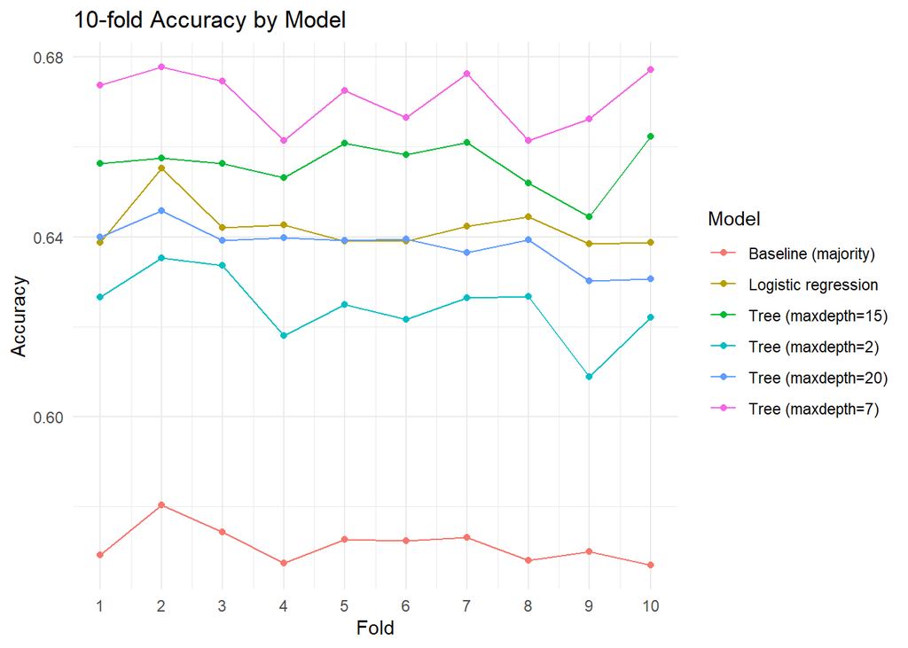

```r
# Uses accuracy vectors from 1(a): baseline_acc, logistic_acc, tree2_acc, tree7_acc, tree15_acc, tree20_acc

k <- length(baseline_acc)

acc_by_fold <- tibble::tibble(
  Fold = 1:k,
  `Baseline (majority)` = baseline_acc,
  `Logistic regression` = logistic_acc,
  `Tree (maxdepth=2)` = tree2_acc,
  `Tree (maxdepth=7)` = tree7_acc,
  `Tree (maxdepth=15)` = tree15_acc,
  `Tree (maxdepth=20)` = tree20_acc
) %>%
  tidyr::pivot_longer(-Fold, names_to = "Model", values_to = "Accuracy")

# Plot: different color per model
ggplot2::ggplot(acc_by_fold, ggplot2::aes(x = Fold, y = Accuracy, color = Model)) +
  ggplot2::geom_line() +
  ggplot2::geom_point() +
  ggplot2::scale_x_continuous(breaks = 1:k) +
  ggplot2::labs(title = "10-fold Accuracy by Model", y = "Accuracy") +
  ggplot2::theme_minimal()
```

```r
# Determine if the same model wins every fold
winners <- acc_by_fold %>%
  dplyr::group_by(Fold) %>%
  dplyr::slice_max(Accuracy, with_ties = FALSE) %>%
  dplyr::ungroup()

print(winners)
```

```
## # A tibble: 10 × 3
##     Fold Model             Accuracy
##    <int> <chr>                <dbl>
##  1     1 Tree (maxdepth=7)    0.674
##  2     2 Tree (maxdepth=7)    0.678
##  3     3 Tree (maxdepth=7)    0.675
##  4     4 Tree (maxdepth=7)    0.661
##  5     5 Tree (maxdepth=7)    0.673
##  6     6 Tree (maxdepth=7)    0.666
##  7     7 Tree (maxdepth=7)    0.676
##  8     8 Tree (maxdepth=7)    0.661
##  9     9 Tree (maxdepth=7)    0.666
## 10    10 Tree (maxdepth=7)    0.677
```

```r
same_winner <- dplyr::n_distinct(winners$Model) == 1
cat("Is the highest-accuracy model the same for every fold? ", same_winner, "\n")
```

```
## Is the highest-accuracy model the same for every fold?  TRUE
```

3. Which of these models has the best average cross-validated performance? Is this different from the best model you found in assignment 1? Which do you trust more and why? Using your best cross-validated model, retrain a model using all of data_train with the best specification and predict probabilities in data_valid. Classify the instances with a cutoff of 0.5 and compute the validation accuracy. Are the cross-validated accuracy and the accuracy in the validation data the same?

Between these two, I would trust the cross-validated model more. Cross-validation averages the model performance across many different splits, so it is more stable and less sensitive to randomness compared to using a single split like in HW 1.

```r
# best model chosen from 1(a): decision tree with maxdepth = 7
formula <- success ~ .

# retrain tree on ALL of data_train
final_fit <- rpart(formula, data = data_train, method = "class",
                   control = rpart.control(maxdepth = 7, cp = -1, minsplit = 2))

# predict probabilities in data_valid
valid_probs <- predict(final_fit, newdata = data_valid)[, "YES"]

# classify with cutoff = 0.5
valid_pred <- ifelse(valid_probs >= 0.5, "YES", "NO")
valid_pred <- factor(valid_pred, levels = levels(data_valid$success))

# compute validation accuracy
valid_acc <- mean(valid_pred == data_valid$success)

# cross-validated accuracy for the best model (Tree depth 7, from 1a results)
cv_acc <- mean(tree7_acc)

cat("Cross-validated accuracy (Tree depth 7):", cv_acc, "\n")
```

```
## Cross-validated accuracy (Tree depth 7): 0.6707755
```

```r
cat("Accuracy of validation data(Tree depth 7):", valid_acc, "\n")
```

```
## Accuracy of validation data(Tree depth 7): 0.6693142
```

As seen above, the Cross-validated accuracy and accuracy of validation data is not exactly equal but VERY CLOSE to each other, with just small difference (less than 1%).

4. Using the predicted probabilities you estimated in the validation data in part (c), make a plot of cutoff vs. accuracy, TPR, and TNR similar to the one I made in class. There should be 100 cutoffs between 0 and 1, incrementing by .01. Which cutoff gives you the highest accuracy? Which cutoff should you use if you want at least 80% FPR? At least 80% TPR?

**ANSWER TO QUESTION 1d HERE:**

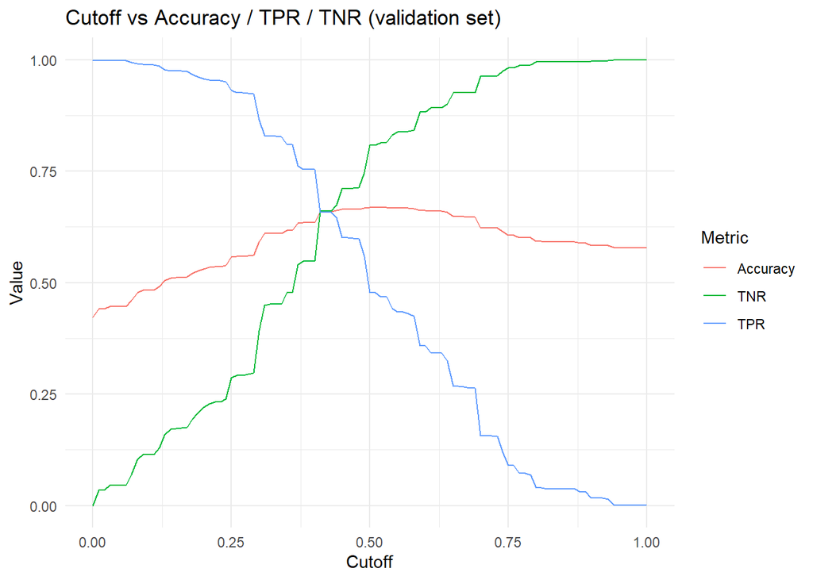

```r
#valid_probs: predicted P(YES) on data_valid using the chosen best model (depth=7)
#data_valid$success: factor with levels c("NO","YES") (or similar)

#Build metrics over 100 cutoffs 0, 0.01, ..., 1.00
cutoffs <- seq(0, 1, by = 0.01)

metrics_for_cutoff <- function(cut) {
  pred <- ifelse(valid_probs >= cut, "YES", "NO")
  pred <- factor(pred, levels = levels(data_valid$success))
  actual <- data_valid$success

  TP <- sum(pred == "YES" & actual == "YES", na.rm = TRUE)
  TN <- sum(pred == "NO"  & actual == "NO",  na.rm = TRUE)
  FP <- sum(pred == "YES" & actual == "NO",  na.rm = TRUE)
  FN <- sum(pred == "NO"  & actual == "YES", na.rm = TRUE)

  TPR <- if ((TP + FN) > 0) TP / (TP + FN) else NA_real_   # sensitivity / recall
  TNR <- if ((TN + FP) > 0) TN / (TN + FP) else NA_real_   # specificity
  ACC <- mean(pred == actual, na.rm = TRUE)
  FPR <- 1 - TNR

  tibble::tibble(
    cutoff = cut,
    Accuracy = ACC,
    TPR = TPR,
    TNR = TNR,
    FPR = FPR
  )
}

metrics_tbl <- purrr::map_dfr(cutoffs, metrics_for_cutoff)

# Plot: cutoff vs Accuracy, TPR, TNR (different colors)
plot_df <- metrics_tbl %>%
  dplyr::select(cutoff, Accuracy, TPR, TNR) %>%
  tidyr::pivot_longer(-cutoff, names_to = "Metric", values_to = "Value")

ggplot2::ggplot(plot_df, ggplot2::aes(x = cutoff, y = Value, color = Metric)) +
  ggplot2::geom_line() +
  ggplot2::labs(title = "Cutoff vs Accuracy / TPR / TNR (validation set)",
                x = "Cutoff", y = "Value") +
  ggplot2::theme_minimal()
```

```r
# Which cutoff gives the highest Accuracy?
best_acc_row <- metrics_tbl %>% dplyr::slice_max(Accuracy, with_ties = FALSE)
best_cutoff_for_accuracy <- best_acc_row$cutoff
best_accuracy <- best_acc_row$Accuracy

# Smallest cutoff > 0 with at least 80% FPR
cutoff_for_FPR80 <- metrics_tbl %>%
  dplyr::filter(cutoff > 0, FPR >= 0.80) %>%     # <-- skip 0
  dplyr::slice_min(cutoff, with_ties = FALSE) %>%
  dplyr::pull(cutoff)
if (length(cutoff_for_FPR80) == 0) cutoff_for_FPR80 <- NA_real_

# Smallest cutoff > 0 with at least 80% TPR
cutoff_for_TPR80 <- metrics_tbl %>%
  dplyr::filter(cutoff > 0, TPR >= 0.80) %>%     # <-- skip 0
  dplyr::slice_min(cutoff, with_ties = FALSE) %>%
  dplyr::pull(cutoff)
if (length(cutoff_for_TPR80) == 0) cutoff_for_TPR80 <- NA_real_

cat("Highest Accuracy at cutoff =", best_cutoff_for_accuracy,
    "with Accuracy =", round(best_accuracy, 4), "\n")
```

```
## Highest Accuracy at cutoff = 0.5 with Accuracy = 0.6693
```

```r
cat("Smallest cutoff > 0 achieving at least 80% FPR:", cutoff_for_FPR80, "\n")
```

```
## Smallest cutoff > 0 achieving at least 80% FPR: 0.01
```

```r
cat("Smallest cutoff > 0 achieving at least 80% TPR:", cutoff_for_TPR80, "\n")
```

```
## Smallest cutoff > 0 achieving at least 80% TPR: 0.01
```

## 2: ROC and AUC

1. Now estimate probabilities in data_valid for each remaining model. You should end up with 6 arrays of predicted probabilities, including the one you have already generated for your best cross-validated model: the baseline, logistic regression, and classification trees with maxdepth = 2, 7, 15, and 20.

**ANSWER TO QUESTION 2a HERE:**

```r
# ## Baseline:
p_yes_train <- mean(data_train$success == "YES", na.rm = TRUE)
p_base_valid <- rep(p_yes_train, nrow(data_valid))

# ## Logistic regression
p_log_valid <- log_tr_pred(data_train, data_valid, formula)

# ## Trees at depths 2, 7, 15, 20
p_tree2_valid <- tree_tr_pred(data_train, data_valid, formula, treedepth = 2)
p_tree7_valid <- tree_tr_pred(data_train, data_valid, formula, treedepth = 7)
p_tree15_valid <- tree_tr_pred(data_train, data_valid, formula, treedepth = 15)
p_tree20_valid <- tree_tr_pred(data_train, data_valid, formula, treedepth = 20)

prob_table_wide <- tibble(row_id = seq_len(nrow(data_valid)), baseline = p_base_valid, logistic = p_log_valid, tree2 = p_tree2_valid, tree_7 = p_tree7_valid, tree_15 = p_tree15_valid, tree_20 = p_tree20_valid)

print(prob_table_wide)
```

```
## # A tibble: 28,580 × 7
##    row_id baseline logistic tree2 tree_7 tree_15 tree_20
##     <int>    <dbl>    <dbl> <dbl>  <dbl>   <dbl>   <dbl>
##  1      1    0.429    0.547 0.588 0.434   0.481    0.633
##  2      2    0.429    0.566 0.427 0.583   0.778    1
##  3      3    0.429    0.353 0.427 0.493   0.0465   0
##  4      4    0.429    0.527 0.588 0.538   0.744    1
##  5      5    0.429    0.225 0.252 0.0765  0.128    0.2
##  6      6    0.429    0.313 0.427 0.299   0.159    0.128
##  7      7    0.429    0.624 0.588 0.434   0.481    0.633
##  8      8    0.429    0.715 0.588 0.634   0.814    1
##  9      9    0.429    0.803 0.588 0.731   0.809    0.834
## 10     10    0.429    0.307 0.427 0.487   0.518    1
## # ℹ 28,570 more rows
```

2. Compute the AUC for each of the 6 models. Does the highest-AUC model also have the highest accuracy given a cutoff of 0.5?

```r
library(pROC)

# actual outcomes
y_valid <- data_valid$success  # factor with levels c("NO","YES")

# collect all six sets of predicted probabilities
models <- list(
  "Baseline"      = p_base_valid,
  "Logistic"      = p_log_valid,
  "Tree depth 2"  = p_tree2_valid,
  "Tree depth 7"  = p_tree7_valid,
  "Tree depth 15" = p_tree15_valid,
  "Tree depth 20" = p_tree20_valid
)

# helper: accuracy at cutoff = 0.5
acc_at_05 <- function(probs, actual) {
  preds <- ifelse(probs >= 0.5, "YES", "NO")
  mean(factor(preds, levels = levels(actual)) == actual, na.rm = TRUE)
}

# compute AUC and accuracy, skipping rows with NA probs
compute_metrics <- function(probs, actual) {
  keep <- !is.na(probs)
  if (sum(keep) == 0) {
    return(c(Accuracy = NA, AUC = NA))
  }
  acc <- acc_at_05(probs[keep], actual[keep])
  auc_val <- auc(roc(actual[keep], probs[keep]))
  c(Accuracy = acc, AUC = auc_val)
}

results_mat <- sapply(models, compute_metrics, actual = y_valid)

results_4b <- tibble::tibble(
  Model = colnames(results_mat),
  Accuracy_at_0.5 = round(results_mat["Accuracy", ], 4),
  AUC = round(results_mat["AUC", ], 4)
) %>%
  dplyr::arrange(desc(AUC)) #arrange the models in desc order of their AUC

results_4b
```

| Model | Accuracy_at_0.5 | AUC |
| --- | --- | --- |
| Tree depth 7 | 0.6693 | 0.7211 |
| Tree depth 15 | 0.6588 | 0.6913 |
| Logistic | 0.6441 | 0.6819 |
| Tree depth 20 | 0.6438 | 0.6490 |
| Tree depth 2 | 0.6266 | 0.6286 |
| Baseline | 0.5785 | 0.5000 |

3. Create an ROC plot including ROC curves for each of the 6 models. Make sure to depict them using different colors. Is the highest-AUC model consistently the best, across all FPR values?

**ANSWER TO QUESTION 2c HERE:** The highest-AUC model(decision tree at depth=7) is the best across MOST of the FPR values, but NOT ACROSS ALL. At some values, decision tree at depths=15 fare slightly better than this model.

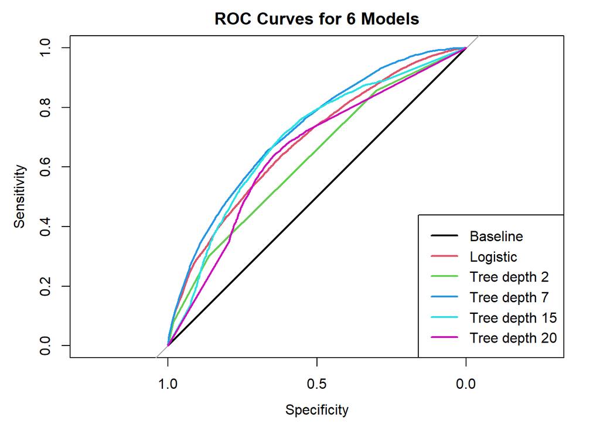

```r
library(pROC)

# actual labels
y_valid <- data_valid$success

# six models from 4(b)
models <- list(
  "Baseline"      = p_base_valid,
  "Logistic"      = p_log_valid,
  "Tree depth 2"  = p_tree2_valid,
  "Tree depth 7"  = p_tree7_valid,
  "Tree depth 15" = p_tree15_valid,
  "Tree depth 20" = p_tree20_valid
)

# build ROC objects (drop NAs)
roc_list <- lapply(models, function(p) {
  keep <- !is.na(p)
  roc(y_valid[keep], p[keep], quiet = TRUE)
})

# plot all ROC curves
plot(roc_list[[1]], col = 1, lwd = 2, main = "ROC Curves for 6 Models")
for (i in 2:length(roc_list)) {
  plot(roc_list[[i]], col = i, lwd = 2, add = TRUE)
}
legend("bottomright", legend = names(models), col = 1:6, lwd = 2)
```

```r
# also print AUC values for clarity
auc_vals <- sapply(roc_list, auc)
auc_vals
```

```
##      Baseline      Logistic  Tree depth 2  Tree depth 7 Tree depth 15
##     0.5000000     0.6818618     0.6285712     0.7211439     0.6912777
## Tree depth 20
##     0.6490421
```

## 3: Feature Engineering

So far, we have been using a small and relatively “clean” subset of the data. Many of the other features will require some cleaning in order to be used in a model.

The new dataframe `original_data` has all of the original features, plus the new ones that we created and processed in HW1. We will use this going forward.

```r
original_data <- rbind(train, test) %>%
  mutate(
    video_category_id = as.factor(video_category_id),
    channel_country = as.factor(channel_country),
    video_definition = as.factor(video_definition),
    success = as.factor(success),
    likes_per_view = ifelse(video_view_count > 0, video_like_count / video_view_count, 0),
    comments_per_view = ifelse(video_view_count > 0, video_comment_count / video_view_count, 0),
    is_hd = ifelse(video_definition == "hd", 1, 0),
  ) %>%
  group_by(video_category_id) %>%
  mutate(
    mean_views = mean(video_view_count, na.rm = TRUE),
    high_for_category = ifelse(video_view_count > mean_views, "YES", "NO")
  ) %>%
  select(-mean_views) %>%
  ungroup() %>%
  mutate(high_for_category = as.factor(high_for_category))
```

1. The following columns (among others) may have missing values:
- video_tags
- channel_country
- channel_description
- video_description
- video_default_thumbnail

Impute the missing values using the approaches we discussed in class. Make sure to convert any of these features to factors, if that is appropriate.

**ANSWER TO QUESTION 3a HERE:**

```r
# Impute missing values for selected columns

original_data <- original_data %>%
  mutate(
    video_tags = ifelse(is.na(video_tags), "UNKNOWN", video_tags),
    channel_country = ifelse(is.na(channel_country), "UNKNOWN", as.character(channel_country)),
    channel_description = ifelse(is.na(channel_description), "", channel_description),
    video_description = ifelse(is.na(video_description), "", video_description),
    video_default_thumbnail = ifelse(is.na(video_default_thumbnail), "MISSING", video_default_thumbnail)
  ) %>%
  # Convert appropriate variables to factors
  mutate(
    video_tags = as.factor(video_tags),
    channel_country = as.factor(channel_country),
    video_default_thumbnail = as.factor(video_default_thumbnail)
  )
```

2. The `video_category_id` column contains many categories, but some of them have very few videos. Group any `video_category_id` containing <= 50 instances into a new category called ‘Other’ and convert the variable into a factor. How many levels does the factor have?

```r
# Count how many rows per category
cat_counts <- original_data %>%
  count(video_category_id)

# Replace categories with <= 50 instances by "Other"
original_data <- original_data %>%
  mutate(video_category_id = ifelse(video_category_id %in% cat_counts$video_category_id[cat_counts$n <= 50],
                                    "Other", as.character(video_category_id))) %>%
  mutate(video_category_id = as.factor(video_category_id))

# How many levels now?
n_levels <- nlevels(original_data$video_category_id)
n_levels
```

```
## [1] 14
```

3. Find the number of tags for each video. Make sure to deal with NA’s!

**ANSWER TO QUESTION 3c HERE:**

```r
# Count the number of tags per video
# Assume tags are stored as a string separated by "|"
original_data <- original_data %>%
  mutate(
    n_tags = ifelse(is.na(video_tags),
                    0,   # if missing, 0 tags
                    stringr::str_count(as.character(video_tags), "\\|") + 1)
  )

# Quick preview
original_data %>% select(video_tags, n_tags) %>% head(10) #head(10) shows only first 10 videos.
```

| video_tags | n_tags |
| --- | --- |
| selly,vlog,vlogger,5gang,andrei selaru | 1 |
| UNKNOWN | 1 |
| UNKNOWN | 1 |
| dancehall,reggae,onerpm,Music,official,audio,video,jamaica,reggae music,dancehall 2025 mix,new music,trop life,dancehall music,reggae 2025,trending,jamaican,caribbean music,trinidad and tobago,trap,be… | 1 |
| жуткие пасхалки,жп,жуткие пасхалки в играх,секреты,мифы,страшные пасхалки,страшные секреты в играх,мистери форс,mysteryforce | 1 |
| Midian Lima,Jonas,Jonas Ao Vivo,Midian Lima - Jonas,Jonas - Midian Lima,Midian Lima Ao Vivo,midian lima jonas clipe oficial,midian lima clipe oficial,midian lima,jonas,ao vivo,midian lima jonas,mk mus… | 1 |
| 這群人,TGOP,搞笑影片,This,Group,Of,People,茵聲,展榮,董仔,尼克,木星,石頭,喜劇演員,搞笑團體,好笑,有趣,趣味,feat.,經典語錄,牧昕,鄭茵聲,黑鬼兒 | 1 |
| rtl,rtl hr,rtl hrvatska,hrvatska | 1 |
| UNKNOWN | 1 |
| colors tv,colorstv,hindi serials | 1 |

4. Select all of the features used in HW1, plus the new ones you just cleaned and created. Make sure to also select success and original_set. The list of variables selected should be:
- video_view_count
- video_like_count
- video_comment_count
- video_duration_seconds
- video_category_id
- channel_country
- video_definition
- channel_subscriber_count
- likes_per_view
- comments_per_view
- is_hd
- high_for_category
- num_tags
- success
- original_set

Create a one-hot encoding, split the resulting dataframe into labeled and unlabeled data called `feats_labeled` and `feats_unlabeled` using the `original_set` variable (then drop it from both), and convert `success` into a factor.

**ANSWER TO QUESTION 3d HERE:**

```r
library(dplyr)
library(caret)
library(stringr)

# 1) Ensure the tag-count column name matches spec: num_tags
if ("n_tags" %in% names(original_data)) {
  original_data <- original_data %>% rename(num_tags = n_tags)
} else if (!"num_tags" %in% names(original_data)) {
  # fallback: compute from video_tags if needed
  original_data <- original_data %>%
    mutate(num_tags = ifelse(is.na(video_tags), 0,
                             stringr::str_count(as.character(video_tags), "\\|") + 1))
}

# 2) Make sure categorical fields are factors, success too
original_data <- original_data %>%
  mutate(
    video_category_id   = as.factor(video_category_id),
    channel_country     = as.factor(channel_country),
    video_definition    = as.factor(video_definition),
    high_for_category   = as.factor(high_for_category),
    success             = as.factor(success)
  )

# 3) Select exactly the requested variables
feats_selected <- original_data %>%
  select(
    video_view_count,
    video_like_count,
    video_comment_count,
    video_duration_seconds,
    video_category_id,
    channel_country,
    video_definition,
    channel_subscriber_count,
    likes_per_view,
    comments_per_view,
    is_hd,
    high_for_category,
    num_tags,
    success,
    original_set
  )

# 4) One-hot encode predictors (exclude success & original_set from encoding)
dv <- caret::dummyVars(
  ~ . - success - original_set,
  data = feats_selected,
  fullRank = TRUE   # drop one level per factor to avoid collinearity
)

X_encoded <- as.data.frame(predict(dv, newdata = feats_selected))

# 5) Attach target + split key back
feats_all <- cbind(
  X_encoded,
  success      = feats_selected$success,
  original_set = feats_selected$original_set
)

# 6) Split into labeled and unlabeled by original_set, then drop original_set
feats_labeled <- feats_all %>%
  filter(original_set == "tr") %>%
  select(-original_set) %>%
  mutate(success = as.factor(success))

feats_unlabeled <- feats_all %>%
  filter(original_set == "te") %>%
  select(-original_set) %>%
  mutate(success = as.factor(success))  # ok if it's a placeholder; keeps schema consistent
```